# Yedla Sowmya_Dissertation

```python
import os
os.getcwd()
```

```
'C:\\Users\\yedla'
```

```python
os.listdir()
```

[output not shown]

Loading RNA FILE

```python
import pandas as pd

rna_path = r"C:\Users\yedla\OneDrive\Documents\Dissertation file_Sowmya\tcga_rna_seq.gz.gz"

rna_df = pd.read_csv(rna_path, sep="\t")

print("Shape:", rna_df.shape)
rna_df.head()
```

```
Shape: (20530, 1219)
```

|  | sample | TCGA-AR-A5QQ-01 | TCGA-D8-A1JA-01 | TCGA-BH-A0BQ-01 | TCGA-BH-A0BT-01 | TCGA-A8-A06X-01 | TCGA-A8-A096-01 | TCGA-BH-A0C7-01 | TCGA-AC-A5XU-01 | TCGA-PE-A5DE-01 | ... | TCGA-A7-A13E-11 | TCGA-C8-A8HP-01 | TCGA-E9-A5FL-01 | TCGA-AC-A2FB-11 | TCGA-E2-A15F-01 | TCGA-A2-A3XT-01 | TCGA-B6-A0X7-01 | TCGA-BH-A1EV-11 | TCGA-3C-AALJ-01 | TCGA-B6-A0X1-01 |
| --- | --- | --- | --- | --- | --- | --- | --- | --- | --- | --- | --- | --- | --- | --- | --- | --- | --- | --- | --- | --- | --- |
| 0 | ARHGEF10L | 9.5074 | 7.4346 | 9.3216 | 9.0198 | 9.6417 | 9.7665 | 10.0931 | 9.1524 | 9.9398 | ... | 9.6265 | 10.1826 | 9.9199 | 9.9090 | 10.0334 | 11.5144 | 10.5745 | 9.4048 | 10.9468 | 10.3164 |
| 1 | HIF3A | 1.5787 | 3.6607 | 2.7224 | 1.3414 | 0.5819 | 0.2738 | 3.6090 | 0.4738 | 2.9378 | ... | 8.1546 | 2.2159 | 3.8645 | 8.1872 | 0.8836 | 1.3169 | 4.0696 | 7.2537 | 0.9310 | 2.4191 |
| 2 | RNF17 | 0.0000 | 0.6245 | 0.5526 | 0.0000 | 0.0000 | 0.8765 | 0.0000 | 0.0000 | 0.0000 | ... | 0.0000 | 0.0000 | 3.7305 | 0.0000 | 0.0000 | 1.1329 | 0.4258 | 0.0000 | 0.0000 | 0.0000 |
| 3 | RNF10 | 11.3676 | 11.9181 | 11.9665 | 13.1881 | 12.0036 | 11.8118 | 11.3820 | 11.5004 | 12.2055 | ... | 11.9869 | 12.2653 | 12.4815 | 11.8263 | 12.0135 | 11.5818 | 11.8663 | 11.5460 | 12.2616 | 12.1570 |
| 4 | RNF11 | 11.1292 | 13.5273 | 11.4105 | 11.0911 | 11.2545 | 10.8554 | 10.7663 | 10.4358 | 11.2210 | ... | 11.9344 | 11.4117 | 10.4902 | 11.5754 | 10.8370 | 10.2736 | 10.7644 | 11.8774 | 10.7842 | 11.2420 |

5 rows × 1219 columns

Prepare RNA Data for Machine Learning

Right now:

Rows = genes Columns = samples

But ML needs:

Rows = samples Columns = genes

So we must transpose.

STEP 1 — Set Gene Column as Index

```python
rna_df = rna_df.set_index(rna_df.columns[0])
rna_df.head()
```

| sample | TCGA-AR-A5QQ-01 | TCGA-D8-A1JA-01 | TCGA-BH-A0BQ-01 | TCGA-BH-A0BT-01 | TCGA-A8-A06X-01 | TCGA-A8-A096-01 | TCGA-BH-A0C7-01 | TCGA-AC-A5XU-01 | TCGA-PE-A5DE-01 | TCGA-PE-A5DC-01 | ... | TCGA-A7-A13E-11 | TCGA-C8-A8HP-01 | TCGA-E9-A5FL-01 | TCGA-AC-A2FB-11 | TCGA-E2-A15F-01 | TCGA-A2-A3XT-01 | TCGA-B6-A0X7-01 | TCGA-BH-A1EV-11 | TCGA-3C-AALJ-01 | TCGA-B6-A0X1-01 |
| --- | --- | --- | --- | --- | --- | --- | --- | --- | --- | --- | --- | --- | --- | --- | --- | --- | --- | --- | --- | --- | --- |
| ARHGEF10L | 9.5074 | 7.4346 | 9.3216 | 9.0198 | 9.6417 | 9.7665 | 10.0931 | 9.1524 | 9.9398 | 9.6287 | ... | 9.6265 | 10.1826 | 9.9199 | 9.9090 | 10.0334 | 11.5144 | 10.5745 | 9.4048 | 10.9468 | 10.3164 |
| HIF3A | 1.5787 | 3.6607 | 2.7224 | 1.3414 | 0.5819 | 0.2738 | 3.6090 | 0.4738 | 2.9378 | 4.1136 | ... | 8.1546 | 2.2159 | 3.8645 | 8.1872 | 0.8836 | 1.3169 | 4.0696 | 7.2537 | 0.9310 | 2.4191 |
| RNF17 | 0.0000 | 0.6245 | 0.5526 | 0.0000 | 0.0000 | 0.8765 | 0.0000 | 0.0000 | 0.0000 | 0.0000 | ... | 0.0000 | 0.0000 | 3.7305 | 0.0000 | 0.0000 | 1.1329 | 0.4258 | 0.0000 | 0.0000 | 0.0000 |
| RNF10 | 11.3676 | 11.9181 | 11.9665 | 13.1881 | 12.0036 | 11.8118 | 11.3820 | 11.5004 | 12.2055 | 12.1312 | ... | 11.9869 | 12.2653 | 12.4815 | 11.8263 | 12.0135 | 11.5818 | 11.8663 | 11.5460 | 12.2616 | 12.1570 |
| RNF11 | 11.1292 | 13.5273 | 11.4105 | 11.0911 | 11.2545 | 10.8554 | 10.7663 | 10.4358 | 11.2210 | 10.8013 | ... | 11.9344 | 11.4117 | 10.4902 | 11.5754 | 10.8370 | 10.2736 | 10.7644 | 11.8774 | 10.7842 | 11.2420 |

5 rows × 1218 columns

STEP 2 — Transpose Data

```python
rna_df = rna_df.T

print("After transpose:", rna_df.shape)
rna_df.head()
```

```
After transpose: (1218, 20530)
```

| sample | ARHGEF10L | HIF3A | RNF17 | RNF10 | RNF11 | RNF13 | GTF2IP1 | REM1 | MTVR2 | RTN4RL2 | ... | TULP2 | NPY5R | GNGT2 | GNGT1 | TULP3 | PTRF | BCL6B | GSTK1 | SELP | SELS |
| --- | --- | --- | --- | --- | --- | --- | --- | --- | --- | --- | --- | --- | --- | --- | --- | --- | --- | --- | --- | --- | --- |
| TCGA-AR-A5QQ-01 | 9.5074 | 1.5787 | 0.0000 | 11.3676 | 11.1292 | 9.9722 | 11.5966 | 3.2396 | 0.0000 | 3.5764 | ... | 0.5819 | 0.0000 | 5.3307 | 0.5819 | 9.1928 | 13.8808 | 7.3830 | 11.4289 | 7.8456 | 10.7384 |
| TCGA-D8-A1JA-01 | 7.4346 | 3.6607 | 0.6245 | 11.9181 | 13.5273 | 10.8702 | 12.3048 | 2.5547 | 0.0000 | 6.0854 | ... | 1.0589 | 0.0000 | 3.1017 | 3.7793 | 9.8340 | 10.7066 | 7.2467 | 9.1673 | 0.0000 | 10.1225 |
| TCGA-BH-A0BQ-01 | 9.3216 | 2.7224 | 0.5526 | 11.9665 | 11.4105 | 10.4406 | 12.8186 | 4.7115 | 0.0000 | 5.8329 | ... | 0.0000 | 2.7224 | 4.2976 | 0.0000 | 9.2304 | 12.9973 | 8.3374 | 11.3400 | 8.3765 | 9.9367 |
| TCGA-BH-A0BT-01 | 9.0198 | 1.3414 | 0.0000 | 13.1881 | 11.0911 | 10.4244 | 12.6427 | 2.7553 | 0.0000 | 4.6308 | ... | 0.0000 | 2.9823 | 4.3067 | 0.0000 | 8.7816 | 12.3298 | 7.7036 | 11.3025 | 7.0585 | 9.3784 |
| TCGA-A8-A06X-01 | 9.6417 | 0.5819 | 0.0000 | 12.0036 | 11.2545 | 10.1480 | 12.6622 | 4.2765 | 1.8007 | 4.4505 | ... | 1.3163 | 0.5819 | 3.5764 | 0.0000 | 9.3024 | 11.3338 | 7.7186 | 10.6898 | 7.0992 | 11.1740 |

5 rows × 20530 columns

```python
rna_df.index[:5]
```

```
Index(['TCGA-AR-A5QQ-01', 'TCGA-D8-A1JA-01', 'TCGA-BH-A0BQ-01',
       'TCGA-BH-A0BT-01', 'TCGA-A8-A06X-01'],
      dtype='object')
```

```python
rna_df.columns[:5]
```

```
Index(['ARHGEF10L', 'HIF3A', 'RNF17', 'RNF10', 'RNF11'], dtype='object', name='sample')
```

# STEP 1 — Load RPPA File

```python
# Load RPPA protein data

rppa_path = r"C:\Users\yedla\OneDrive\Documents\Dissertation file_Sowmya\TCGA.BRCA.sampleMap_RPPA.gz"

rppa_df = pd.read_csv(rppa_path, sep="\t")

print("Original RPPA shape:", rppa_df.shape)
rppa_df.head()
```

```
Original RPPA shape: (281, 938)
```

|  | sample | TCGA-A7-A4SD-01 | TCGA-E2-A15A-06 | TCGA-OL-A66K-01 | TCGA-AQ-A54O-01 | TCGA-JL-A3YW-01 | TCGA-OL-A5D8-01 | TCGA-E9-A5FL-01 | TCGA-OL-A66J-01 | TCGA-AC-A62X-01 | ... | TCGA-BH-A0DG-01 | TCGA-A2-A0T0-01 | TCGA-C8-A12L-01 | TCGA-A7-A0CG-01 | TCGA-D8-A142-01 | TCGA-A2-A0ER-01 | TCGA-A8-A08A-01 | TCGA-D8-A145-01 | TCGA-A8-A07P-01 | TCGA-BH-A0BV-01 |
| --- | --- | --- | --- | --- | --- | --- | --- | --- | --- | --- | --- | --- | --- | --- | --- | --- | --- | --- | --- | --- | --- |
| 0 | 14-3-3_beta-R-V | -0.111867 | -0.227059 | 0.442161 | -0.053226 | -0.033047 | -0.043539 | -0.236816 | -0.084417 | -0.148782 | ... | 0.270785 | -0.268162 | -0.162149 | 0.119277 | -0.199935 | 0.516463 | -0.243389 | -0.243811 | 0.004337 | -0.053015 |
| 1 | 14-3-3_epsilon-M-C | 0.055732 | -0.141146 | 0.124513 | 0.106420 | -0.117312 | 0.114433 | -0.035429 | -0.520502 | 0.008427 | ... | 0.457536 | -0.180333 | 0.000000 | 0.039602 | -0.079528 | 0.520671 | -0.282516 | 0.192007 | -0.181983 | 0.113322 |
| 2 | 14-3-3_zeta-R-V | -0.275867 | 0.164531 | -0.345148 | 0.428807 | 0.182311 | 0.445767 | 0.356124 | -0.246709 | 0.004052 | ... | -0.082737 | -0.028467 | 0.034230 | 0.278677 | 0.220053 | -0.350128 | -0.434799 | 0.535172 | 0.787150 | -0.065924 |
| 3 | 4E-BP1-R-V | 0.405752 | 0.034719 | -0.265526 | 0.562209 | -0.372718 | -0.175267 | -0.378825 | 0.348962 | 0.882106 | ... | -0.282764 | -0.113686 | 0.427999 | 0.285576 | -0.233124 | -0.496862 | -0.283495 | 0.738314 | -1.221513 | -0.172034 |
| 4 | 4E-BP1_pS65-R-V | 0.041668 | -0.012555 | -0.166973 | 0.022931 | -0.049889 | -0.232404 | 0.052562 | -0.735728 | 0.649354 | ... | -0.152098 | 0.369525 | 0.383592 | -0.274964 | 0.348447 | 0.154828 | -0.083645 | 0.382707 | -0.497053 | -0.067644 |

5 rows × 938 columns

STEP 2 — Set Protein Names as Index

```python
rppa_df.set_index(rppa_df.columns[0], inplace=True)

print("After setting index:", rppa_df.shape)
```

```
After setting index: (281, 937)
```

STEP 3 — Transpose RPPA

```python
rppa_df = rppa_df.T

print("After transpose:", rppa_df.shape)
rppa_df.head()
```

```
After transpose: (937, 281)
```

| sample | 14-3-3_beta-R-V | 14-3-3_epsilon-M-C | 14-3-3_zeta-R-V | 4E-BP1-R-V | 4E-BP1_pS65-R-V | 4E-BP1_pT37_T46-R-V | 4E-BP1_pT70-R-V | 53BP1-R-E | A-Raf_pS299-R-C | ACC_pS79-R-V | ... | ERCC1-M-E | MSH2-M-E | MSH6-R-E | Bcl-xL-R-C | Chk1-R-V | HER2_pY1248-R-V | HER3-M-C | HER3_pY1289-R-V | Smad4-M-C | JNK_pT183_pY185-R-C |
| --- | --- | --- | --- | --- | --- | --- | --- | --- | --- | --- | --- | --- | --- | --- | --- | --- | --- | --- | --- | --- | --- |
| TCGA-A7-A4SD-01 | -0.111867 | 0.055732 | -0.275867 | 0.405752 | 0.041668 | 0.430052 | 0.382415 | 0.355998 | 0.045882 | 0.005606 | ... | NaN | NaN | NaN | NaN | NaN | NaN | NaN | NaN | NaN | NaN |
| TCGA-E2-A15A-06 | -0.227059 | -0.141146 | 0.164531 | 0.034719 | -0.012555 | 0.517896 | 0.152698 | 0.025036 | -0.367173 | 0.158209 | ... | 0.100208 | -0.053895 | 0.340938 | NaN | NaN | NaN | NaN | NaN | NaN | NaN |
| TCGA-OL-A66K-01 | 0.442161 | 0.124513 | -0.345148 | -0.265526 | -0.166973 | 0.093021 | 0.267432 | -0.089752 | -0.024757 | -0.329915 | ... | NaN | NaN | NaN | NaN | NaN | NaN | NaN | NaN | NaN | NaN |
| TCGA-AQ-A54O-01 | -0.053226 | 0.106420 | 0.428807 | 0.562209 | 0.022931 | -0.020216 | -0.050689 | 0.612467 | 0.142419 | 1.101916 | ... | NaN | NaN | NaN | NaN | NaN | NaN | NaN | NaN | NaN | NaN |
| TCGA-JL-A3YW-01 | -0.033047 | -0.117312 | 0.182311 | -0.372718 | -0.049889 | -0.504711 | -0.065410 | -0.148092 | 0.334204 | 0.287604 | ... | 0.146831 | 0.156876 | 0.592055 | NaN | NaN | NaN | NaN | NaN | NaN | NaN |

5 rows × 281 columns

STEP 4 — Match Overlapping Samples

Not all 937 RPPA samples are present in RNA. We must keep only patients that exist in BOTH datasets.

Step 4.1 — Check Sample ID Format

First, let’s inspect sample IDs:

```python
print("RNA sample example:")
print(rna_df.index[:5])

print("\nRPPA sample example:")
print(rppa_df.index[:5])
```

```
RNA sample example:
Index(['TCGA-AR-A5QQ-01', 'TCGA-D8-A1JA-01', 'TCGA-BH-A0BQ-01',
       'TCGA-BH-A0BT-01', 'TCGA-A8-A06X-01'],
      dtype='object')

RPPA sample example:
Index(['TCGA-A7-A4SD-01', 'TCGA-E2-A15A-06', 'TCGA-OL-A66K-01',
       'TCGA-AQ-A54O-01', 'TCGA-JL-A3YW-01'],
      dtype='object')
```

Step 4.2 — Standardize Sample IDs (Important!)

TCGA IDs sometimes include extra parts like:

TCGA-XX-XXXX-01A-...

We only need the first 12 characters:

TCGA-XX-XXXX

```python
print("RNA example:", rna_df.index[:5])
print("RPPA example:", rppa_df.index[:5])
```

```
RNA example: Index(['TCGA-AR-A5QQ-01', 'TCGA-D8-A1JA-01', 'TCGA-BH-A0BQ-01',
       'TCGA-BH-A0BT-01', 'TCGA-A8-A06X-01'],
      dtype='object')
RPPA example: Index(['TCGA-A7-A4SD-01', 'TCGA-E2-A15A-06', 'TCGA-OL-A66K-01',
       'TCGA-AQ-A54O-01', 'TCGA-JL-A3YW-01'],
      dtype='object')
```

Step 4.3 — Find Common Samples

Now find overlap:

```python
common_samples = rna_df.index.intersection(rppa_df.index)

print("Number of common samples:", len(common_samples))
```

```
Number of common samples: 926
```

Step 4.4 — Subset Both Datasets

Now keep only overlapping samples:

```python
# 1️ Standardize sample IDs
rna_df.index = rna_df.index.str[:12]
rppa_df.index = rppa_df.index.str[:12]

# 2️ Remove duplicates
rna_df = rna_df[~rna_df.index.duplicated(keep='first')]
rppa_df = rppa_df[~rppa_df.index.duplicated(keep='first')]

# 3️ Recompute common samples
common_samples = rna_df.index.intersection(rppa_df.index)

print("Number of overlapping patients:", len(common_samples))

# 4️ Subset both datasets
rna_common = rna_df.loc[common_samples]
rppa_common = rppa_df.loc[common_samples]

print("RNA after matching:", rna_common.shape)
print("RPPA after matching:", rppa_common.shape)
```

```
Number of overlapping patients: 885
RNA after matching: (885, 20530)
RPPA after matching: (885, 281)
```

```python
rppa_df.columns[:5]
```

```
Index(['14-3-3_beta-R-V', '14-3-3_epsilon-M-C', '14-3-3_zeta-R-V',
       '4E-BP1-R-V', '4E-BP1_pS65-R-V'],
      dtype='object', name='sample')
```

```python
rppa_df.index[:5]
```

```
Index(['TCGA-A7-A4SD', 'TCGA-E2-A15A', 'TCGA-OL-A66K', 'TCGA-AQ-A54O',
       'TCGA-JL-A3YW'],
      dtype='object')
```

# Load Phenotype (PAM50 Labels)

STEP 1 — Load Clinical Matrix

```python
# Load clinical phenotype data

pheno_path = r"C:\Users\yedla\OneDrive\Documents\Dissertation file_Sowmya\TCGA.BRCA.sampleMap_BRCA_clinicalMatrix"

pheno_df = pd.read_csv(pheno_path, sep="\t")

print("Original phenotype shape:", pheno_df.shape)
pheno_df.head()
```

```
Original phenotype shape: (1247, 194)
```

|  | sampleID | AJCC_Stage_nature2012 | Age_at_Initial_Pathologic_Diagnosis_nature2012 | CN_Clusters_nature2012 | Converted_Stage_nature2012 | Days_to_Date_of_Last_Contact_nature2012 | Days_to_date_of_Death_nature2012 | ER_Status_nature2012 | Gender_nature2012 | HER2_Final_Status_nature2012 | ... | _GENOMIC_ID_TCGA_BRCA_mutation_wustl_gene | _GENOMIC_ID_TCGA_BRCA_miRNA_GA | _GENOMIC_ID_TCGA_BRCA_exp_HiSeqV2_percentile | _GENOMIC_ID_data/public/TCGA/BRCA/miRNA_GA_gene | _GENOMIC_ID_TCGA_BRCA_gistic2thd | _GENOMIC_ID_data/public/TCGA/BRCA/miRNA_HiSeq_gene | _GENOMIC_ID_TCGA_BRCA_G4502A_07_3 | _GENOMIC_ID_TCGA_BRCA_exp_HiSeqV2 | _GENOMIC_ID_TCGA_BRCA_gistic2 | _GENOMIC_ID_TCGA_BRCA_PDMarray |
| --- | --- | --- | --- | --- | --- | --- | --- | --- | --- | --- | --- | --- | --- | --- | --- | --- | --- | --- | --- | --- | --- |
| 0 | TCGA-3C-AAAU-01 | NaN | NaN | NaN | NaN | NaN | NaN | NaN | NaN | NaN | ... | NaN | NaN | 6ef883fc-81f3-4089-95e0-86904ffc0d38 | NaN | TCGA-3C-AAAU-01A-11D-A41E-01 | TCGA-3C-AAAU-01 | NaN | 6ef883fc-81f3-4089-95e0-86904ffc0d38 | TCGA-3C-AAAU-01A-11D-A41E-01 | NaN |
| 1 | TCGA-3C-AALI-01 | NaN | NaN | NaN | NaN | NaN | NaN | NaN | NaN | NaN | ... | NaN | NaN | dd8d3665-ec9d-45be-b7b9-a85dac3585e2 | NaN | TCGA-3C-AALI-01A-11D-A41E-01 | TCGA-3C-AALI-01 | NaN | dd8d3665-ec9d-45be-b7b9-a85dac3585e2 | TCGA-3C-AALI-01A-11D-A41E-01 | NaN |
| 2 | TCGA-3C-AALJ-01 | NaN | NaN | NaN | NaN | NaN | NaN | NaN | NaN | NaN | ... | NaN | NaN | c924c2a8-ab41-4499-bb30-79705cc17d45 | NaN | TCGA-3C-AALJ-01A-31D-A41E-01 | TCGA-3C-AALJ-01 | NaN | c924c2a8-ab41-4499-bb30-79705cc17d45 | TCGA-3C-AALJ-01A-31D-A41E-01 | NaN |
| 3 | TCGA-3C-AALK-01 | NaN | NaN | NaN | NaN | NaN | NaN | NaN | NaN | NaN | ... | NaN | NaN | 1a19e068-d213-41ef-aebb-104017a883cc | NaN | TCGA-3C-AALK-01A-11D-A41E-01 | TCGA-3C-AALK-01 | NaN | 1a19e068-d213-41ef-aebb-104017a883cc | TCGA-3C-AALK-01A-11D-A41E-01 | NaN |
| 4 | TCGA-4H-AAAK-01 | NaN | NaN | NaN | NaN | NaN | NaN | NaN | NaN | NaN | ... | NaN | NaN | 2ea9e472-a408-4ae0-975d-50a566f22b2a | NaN | TCGA-4H-AAAK-01A-12D-A41E-01 | TCGA-4H-AAAK-01 | NaN | 2ea9e472-a408-4ae0-975d-50a566f22b2a | TCGA-4H-AAAK-01A-12D-A41E-01 | NaN |

5 rows × 194 columns

STEP 2 — Check Columns

We need to find the PAM50 subtype column.

```python
pheno_df.columns
```

```
Index(['sampleID', 'AJCC_Stage_nature2012',
       'Age_at_Initial_Pathologic_Diagnosis_nature2012',
       'CN_Clusters_nature2012', 'Converted_Stage_nature2012',
       'Days_to_Date_of_Last_Contact_nature2012',
       'Days_to_date_of_Death_nature2012', 'ER_Status_nature2012',
       'Gender_nature2012', 'HER2_Final_Status_nature2012',
       ...
       '_GENOMIC_ID_TCGA_BRCA_mutation_wustl_gene',
       '_GENOMIC_ID_TCGA_BRCA_miRNA_GA',
       '_GENOMIC_ID_TCGA_BRCA_exp_HiSeqV2_percentile',
       '_GENOMIC_ID_data/public/TCGA/BRCA/miRNA_GA_gene',
       '_GENOMIC_ID_TCGA_BRCA_gistic2thd',
       '_GENOMIC_ID_data/public/TCGA/BRCA/miRNA_HiSeq_gene',
       '_GENOMIC_ID_TCGA_BRCA_G4502A_07_3',
       '_GENOMIC_ID_TCGA_BRCA_exp_HiSeqV2', '_GENOMIC_ID_TCGA_BRCA_gistic2',
       '_GENOMIC_ID_TCGA_BRCA_PDMarray'],
      dtype='object', length=194)
```

STEP 3 — Standardize Sample IDs

Like before, we must truncate TCGA IDs.

First check how sample IDs appear:

```python
pheno_df.head()
```

|  | sampleID | AJCC_Stage_nature2012 | Age_at_Initial_Pathologic_Diagnosis_nature2012 | CN_Clusters_nature2012 | Converted_Stage_nature2012 | Days_to_Date_of_Last_Contact_nature2012 | Days_to_date_of_Death_nature2012 | ER_Status_nature2012 | Gender_nature2012 | HER2_Final_Status_nature2012 | ... | _GENOMIC_ID_TCGA_BRCA_mutation_wustl_gene | _GENOMIC_ID_TCGA_BRCA_miRNA_GA | _GENOMIC_ID_TCGA_BRCA_exp_HiSeqV2_percentile | _GENOMIC_ID_data/public/TCGA/BRCA/miRNA_GA_gene | _GENOMIC_ID_TCGA_BRCA_gistic2thd | _GENOMIC_ID_data/public/TCGA/BRCA/miRNA_HiSeq_gene | _GENOMIC_ID_TCGA_BRCA_G4502A_07_3 | _GENOMIC_ID_TCGA_BRCA_exp_HiSeqV2 | _GENOMIC_ID_TCGA_BRCA_gistic2 | _GENOMIC_ID_TCGA_BRCA_PDMarray |
| --- | --- | --- | --- | --- | --- | --- | --- | --- | --- | --- | --- | --- | --- | --- | --- | --- | --- | --- | --- | --- | --- |
| 0 | TCGA-3C-AAAU-01 | NaN | NaN | NaN | NaN | NaN | NaN | NaN | NaN | NaN | ... | NaN | NaN | 6ef883fc-81f3-4089-95e0-86904ffc0d38 | NaN | TCGA-3C-AAAU-01A-11D-A41E-01 | TCGA-3C-AAAU-01 | NaN | 6ef883fc-81f3-4089-95e0-86904ffc0d38 | TCGA-3C-AAAU-01A-11D-A41E-01 | NaN |
| 1 | TCGA-3C-AALI-01 | NaN | NaN | NaN | NaN | NaN | NaN | NaN | NaN | NaN | ... | NaN | NaN | dd8d3665-ec9d-45be-b7b9-a85dac3585e2 | NaN | TCGA-3C-AALI-01A-11D-A41E-01 | TCGA-3C-AALI-01 | NaN | dd8d3665-ec9d-45be-b7b9-a85dac3585e2 | TCGA-3C-AALI-01A-11D-A41E-01 | NaN |
| 2 | TCGA-3C-AALJ-01 | NaN | NaN | NaN | NaN | NaN | NaN | NaN | NaN | NaN | ... | NaN | NaN | c924c2a8-ab41-4499-bb30-79705cc17d45 | NaN | TCGA-3C-AALJ-01A-31D-A41E-01 | TCGA-3C-AALJ-01 | NaN | c924c2a8-ab41-4499-bb30-79705cc17d45 | TCGA-3C-AALJ-01A-31D-A41E-01 | NaN |
| 3 | TCGA-3C-AALK-01 | NaN | NaN | NaN | NaN | NaN | NaN | NaN | NaN | NaN | ... | NaN | NaN | 1a19e068-d213-41ef-aebb-104017a883cc | NaN | TCGA-3C-AALK-01A-11D-A41E-01 | TCGA-3C-AALK-01 | NaN | 1a19e068-d213-41ef-aebb-104017a883cc | TCGA-3C-AALK-01A-11D-A41E-01 | NaN |
| 4 | TCGA-4H-AAAK-01 | NaN | NaN | NaN | NaN | NaN | NaN | NaN | NaN | NaN | ... | NaN | NaN | 2ea9e472-a408-4ae0-975d-50a566f22b2a | NaN | TCGA-4H-AAAK-01A-12D-A41E-01 | TCGA-4H-AAAK-01 | NaN | 2ea9e472-a408-4ae0-975d-50a566f22b2a | TCGA-4H-AAAK-01A-12D-A41E-01 | NaN |

5 rows × 194 columns

```python
print(pheno_df.columns)
```

```
Index(['sampleID', 'AJCC_Stage_nature2012',
       'Age_at_Initial_Pathologic_Diagnosis_nature2012',
       'CN_Clusters_nature2012', 'Converted_Stage_nature2012',
       'Days_to_Date_of_Last_Contact_nature2012',
       'Days_to_date_of_Death_nature2012', 'ER_Status_nature2012',
       'Gender_nature2012', 'HER2_Final_Status_nature2012',
       ...
       '_GENOMIC_ID_TCGA_BRCA_mutation_wustl_gene',
       '_GENOMIC_ID_TCGA_BRCA_miRNA_GA',
       '_GENOMIC_ID_TCGA_BRCA_exp_HiSeqV2_percentile',
       '_GENOMIC_ID_data/public/TCGA/BRCA/miRNA_GA_gene',
       '_GENOMIC_ID_TCGA_BRCA_gistic2thd',
       '_GENOMIC_ID_data/public/TCGA/BRCA/miRNA_HiSeq_gene',
       '_GENOMIC_ID_TCGA_BRCA_G4502A_07_3',
       '_GENOMIC_ID_TCGA_BRCA_exp_HiSeqV2', '_GENOMIC_ID_TCGA_BRCA_gistic2',
       '_GENOMIC_ID_TCGA_BRCA_PDMarray'],
      dtype='object', length=194)
```

```python
print(pheno_df.index[:5])
```

```
RangeIndex(start=0, stop=5, step=1)
```

```python
pheno_df.index = pheno_df.index.astype(str)
pheno_df.index = pheno_df.index.str[:12]

print(pheno_df.index[:5])
```

```
Index(['0', '1', '2', '3', '4'], dtype='object')
```

```python
print("Columns:")
print(pheno_df.columns)

print("\nIndex preview:")
print(pheno_df.index[:5])
```

```
Columns:
Index(['sampleID', 'AJCC_Stage_nature2012',
       'Age_at_Initial_Pathologic_Diagnosis_nature2012',
       'CN_Clusters_nature2012', 'Converted_Stage_nature2012',
       'Days_to_Date_of_Last_Contact_nature2012',
       'Days_to_date_of_Death_nature2012', 'ER_Status_nature2012',
       'Gender_nature2012', 'HER2_Final_Status_nature2012',
       ...
       '_GENOMIC_ID_TCGA_BRCA_mutation_wustl_gene',
       '_GENOMIC_ID_TCGA_BRCA_miRNA_GA',
       '_GENOMIC_ID_TCGA_BRCA_exp_HiSeqV2_percentile',
       '_GENOMIC_ID_data/public/TCGA/BRCA/miRNA_GA_gene',
       '_GENOMIC_ID_TCGA_BRCA_gistic2thd',
       '_GENOMIC_ID_data/public/TCGA/BRCA/miRNA_HiSeq_gene',
       '_GENOMIC_ID_TCGA_BRCA_G4502A_07_3',
       '_GENOMIC_ID_TCGA_BRCA_exp_HiSeqV2', '_GENOMIC_ID_TCGA_BRCA_gistic2',
       '_GENOMIC_ID_TCGA_BRCA_PDMarray'],
      dtype='object', length=194)

Index preview:
Index(['0', '1', '2', '3', '4'], dtype='object')
```

# PAM50 Extraction

Now we need to extract the subtype column.

```python
[col for col in pheno_df.columns if "PAM50" in col]
```

```
['Integrated_Clusters_with_PAM50__nature2012',
 'PAM50Call_RNAseq',
 'PAM50_mRNA_nature2012']
```

STEP 1 — Set sampleID as index

```python
pheno_df.set_index("sampleID", inplace=True)

print("Index preview:")
print(pheno_df.index[:5])
```

```
Index preview:
Index(['TCGA-3C-AAAU-01', 'TCGA-3C-AALI-01', 'TCGA-3C-AALJ-01',
       'TCGA-3C-AALK-01', 'TCGA-4H-AAAK-01'],
      dtype='object', name='sampleID')
```

STEP 2 — Convert to patient-level ID (12 characters)

```python
pheno_df.index = pheno_df.index.astype(str).str[:12]

print("After truncation:")
print(pheno_df.index[:5])
```

```
After truncation:
Index(['TCGA-3C-AAAU', 'TCGA-3C-AALI', 'TCGA-3C-AALJ', 'TCGA-3C-AALK',
       'TCGA-4H-AAAK'],
      dtype='object', name='sampleID')
```

STEP 3 — Extract PAM50 Column

```python
pam50 = pheno_df["PAM50Call_RNAseq"]

print(pam50.value_counts())
```

```
PAM50Call_RNAseq
LumA      434
LumB      194
Basal     142
Normal    119
Her2       67
Name: count, dtype: int64
```

STEP 4 — Remove Duplicate Patients

Sometimes after truncation duplicates appear.

```python
# Remove duplicate patients in PAM50
pam50 = pam50[~pam50.index.duplicated(keep='first')]

print("Are indices unique now?", pam50.index.is_unique)
```

```
Are indices unique now? True
```

STEP 5 — Now Align With RNA

```python
y = pam50.loc[rna_common.index]

print("After alignment:", y.shape)
print("Missing labels:", y.isna().sum())
```

```
After alignment: (885,)
Missing labels: 190
```

```python
valid_mask = y.notna()

rna_final = rna_common.loc[valid_mask]
rppa_final = rppa_common.loc[valid_mask]
y = y.loc[valid_mask]

print("RNA final:", rna_final.shape)
print("RPPA final:", rppa_final.shape)
print("Labels:", y.shape)

print("Indices identical?")
print(rna_final.index.equals(rppa_final.index))
print(rna_final.index.equals(y.index))
```

```
RNA final: (695, 20530)
RPPA final: (695, 281)
Labels: (695,)
Indices identical?
True
True
```

Now remove the "Normal" subtype (small sample size, not tumour)

```python
mask = y != "Normal"

rna_final = rna_final.loc[mask]
rppa_final = rppa_final.loc[mask]
y = y.loc[mask]

print("After removing Normal:")
print(rna_final.shape)
print(y.value_counts())
```

```
After removing Normal:
(678, 20530)
PAM50Call_RNAseq
LumA     332
LumB     164
Basal    121
Her2      61
Name: count, dtype: int64
```

STEP 1 — Early Integration (Concatenate Features)

Combine RNA + RPPA:

```python
X_multi = pd.concat([rna_final, rppa_final], axis=1)

print("Integrated shape:", X_multi.shape)
```

```
Integrated shape: (678, 20811)
```

STEP 2 — Handle Missing Values (Important)

RPPA contains missing values. PCA and ML cannot handle NaN

```python
from sklearn.impute import SimpleImputer
import numpy as np

imputer = SimpleImputer(strategy="median")
X_imputed = imputer.fit_transform(X_multi)

print("Any NaN left?", np.isnan(X_imputed).sum())
```

```
Any NaN left? 0
```

Comparison of Missing Data Imputation Methods

Imports

```python
from sklearn.impute import SimpleImputer, KNNImputer
from sklearn.model_selection import cross_val_score
from sklearn.ensemble import RandomForestClassifier
```

1. Mean,Median and KNN Imputation

```python
imputer_mean = SimpleImputer(strategy='mean')
X_mean = imputer_mean.fit_transform(X_multi)
```

```python
imputer_median = SimpleImputer(strategy='median')
X_median = imputer_median.fit_transform(X_multi)
```

```python
imputer_knn = KNNImputer(n_neighbors=5)
X_knn = imputer_knn.fit_transform(X_multi)
```

2. Define Model

```python
rf = RandomForestClassifier(n_estimators=300, random_state=42)
```

3. Cross validation of Mean, Median and KNN

```python
cv_mean = cross_val_score(rf, X_mean, y, cv=5)
print("Mean CV:", cv_mean.mean())
cv_median = cross_val_score(rf, X_median, y, cv=5)
print("Median CV:", cv_median.mean())
cv_knn = cross_val_score(rf, X_knn, y, cv=5)
print("KNN CV:", cv_knn.mean())
```

```
Mean CV: 0.8599564270152505
Median CV: 0.8599564270152505
KNN CV: 0.8555228758169935
```

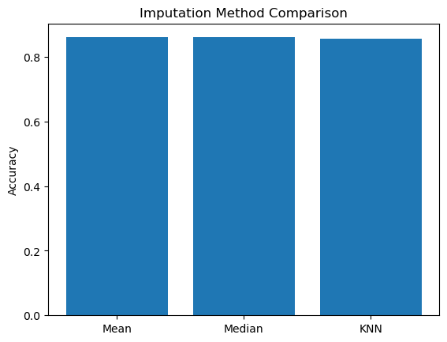

```python
import matplotlib.pyplot as plt

methods = ["Mean", "Median", "KNN"]
scores = [cv_mean.mean(), cv_median.mean(), cv_knn.mean()]

plt.bar(methods, scores)
plt.title("Imputation Method Comparison")
plt.ylabel("Accuracy")

plt.savefig(
    r"C:\Users\yedla\OneDrive\Documents\Dissertation file_Sowmya\Imputation_Comparison.png",
    dpi=300,
    bbox_inches="tight"
)

plt.show()
```

STEP 3 — Feature Scaling

Standardization is required for PCA and SVM.

```python
from sklearn.preprocessing import StandardScaler

scaler = StandardScaler()
X_scaled = scaler.fit_transform(X_imputed)

print("Scaled shape:", X_scaled.shape)
```

```
Scaled shape: (678, 20811)
```

# Scale RNA Only

```python
from sklearn.preprocessing import StandardScaler

scaler_rna = StandardScaler()
rna_scaled = scaler_rna.fit_transform(rna_final)

print(rna_scaled.shape)
```

```
(678, 20530)
```

# Scale RPPA Only

```python
scaler_rppa = StandardScaler()
rppa_scaled = scaler_rppa.fit_transform(rppa_final)

print(rppa_scaled.shape)
```

```
(678, 281)
```

STEP 4 — PCA (Exploratory Analysis)

```python
from sklearn.decomposition import PCA

pca = PCA(n_components=2)
X_pca = pca.fit_transform(X_scaled)

print("Explained variance ratio:", pca.explained_variance_ratio_)
```

```
Explained variance ratio: [0.09077979 0.07718094]
```

STEP 5 — Plot PCA

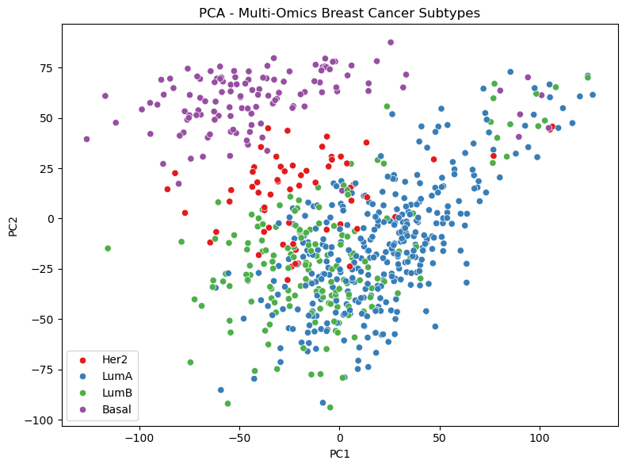

```python
import matplotlib.pyplot as plt
import seaborn as sns

plt.figure(figsize=(8,6))
sns.scatterplot(
    x=X_pca[:,0],
    y=X_pca[:,1],
    hue=y,
    palette="Set1"
)

plt.title("PCA - Multi-Omics Breast Cancer Subtypes")
plt.xlabel("PC1")
plt.ylabel("PC2")
plt.legend()
plt.tight_layout()

plt.savefig(r"C:\Users\yedla\OneDrive\Documents\Dissertation file_Sowmya\PCA_multiomics.png",
            dpi=300)
plt.show()
```

Basal clearly separated

LumA & LumB overlapping

HER2 moderately clustered

That confirms biological structure is preserved.

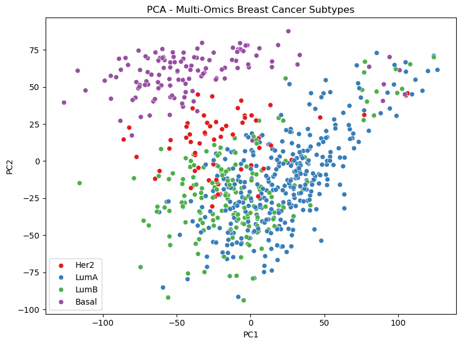

```python
fig = plt.figure(figsize=(8,6))

sns.scatterplot(
    x=X_pca[:,0],
    y=X_pca[:,1],
    hue=y,
    palette="Set1"
)

plt.title("PCA - Multi-Omics Breast Cancer Subtypes")
plt.xlabel("PC1")
plt.ylabel("PC2")
plt.legend()
plt.tight_layout()

fig.savefig(
    r"C:\Users\yedla\OneDrive\Documents\Dissertation file_Sowmya\PCA_multiomics.png",
    dpi=300
)

plt.show()
```

```python
print(X_scaled.shape)
print(y.shape)
print(y.value_counts())
```

```
(678, 20811)
(678,)
PAM50Call_RNAseq
LumA     332
LumB     164
Basal    121
Her2      61
Name: count, dtype: int64
```

STEP 1 — Train/Test Split

```python
print("X shape:", X_scaled.shape)
print("y shape:", y.shape)
```

```
X shape: (678, 20811)
y shape: (678,)
```

```python
from sklearn.model_selection import train_test_split

X_train, X_test, y_train, y_test = train_test_split(
    X_scaled,
    y,
    test_size=0.2,
    stratify=y,
    random_state=42
)

print("Train shape:", X_train.shape)
print("Test shape:", X_test.shape)
```

```
Train shape: (542, 20811)
Test shape: (136, 20811)
```

Comparing of multiple machine learning models

STEP 3 — Train Random Forest

```python
from sklearn.ensemble import RandomForestClassifier

rf = RandomForestClassifier(
    n_estimators=300,
    random_state=42,
    n_jobs=-1
)

rf.fit(X_train, y_train)
```

```
RandomForestClassifier(n_estimators=300, n_jobs=-1, random_state=42)
```

STEP 4 — Evaluate on Random forest Test Set

```python
from sklearn.metrics import accuracy_score, classification_report

y_pred = rf.predict(X_test)

# store accuracy in variable
acc_rf = accuracy_score(y_test, y_pred)

# print results
print("Random Forest Accuracy:", acc_rf)
print("\nClassification Report:\n")
print(classification_report(y_test, y_pred))
```

```
Random Forest Accuracy: 0.8455882352941176

Classification Report:

              precision    recall  f1-score   support

       Basal       1.00      0.88      0.93        24
        Her2       1.00      0.50      0.67        12
        LumA       0.80      0.96      0.87        67
        LumB       0.83      0.73      0.77        33

    accuracy                           0.85       136
   macro avg       0.91      0.76      0.81       136
weighted avg       0.86      0.85      0.84       136
```

STEP 5 — Confusion Matrix Plot

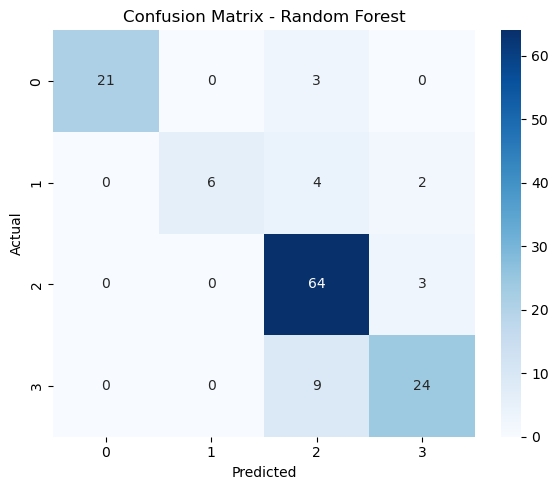

```python
from sklearn.metrics import confusion_matrix
import seaborn as sns
import matplotlib.pyplot as plt

cm = confusion_matrix(y_test, y_pred)

plt.figure(figsize=(6,5))
sns.heatmap(cm, annot=True, fmt='d', cmap='Blues')

plt.xlabel("Predicted")
plt.ylabel("Actual")
plt.title("Confusion Matrix - Random Forest")

plt.tight_layout()

# Save figure (IMPORTANT: before plt.show())
plt.savefig(
    r"C:\Users\yedla\OneDrive\Documents\Dissertation file_Sowmya\Confusion_Matrix_RF.png",
    dpi=300
)

plt.show()
```

STEP 6- Train and Evaluate Logistic Regression

```python
from sklearn.linear_model import LogisticRegression
from sklearn.metrics import accuracy_score

lr = LogisticRegression(max_iter=1000)
lr.fit(X_train, y_train)

y_pred_lr = lr.predict(X_test)
acc_lr = accuracy_score(y_test, y_pred_lr)

print("Logistic Regression Accuracy:", acc_lr)
```

```
Logistic Regression Accuracy: 0.8602941176470589
```

Confusion matrix using logistic regression

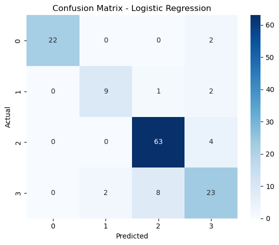

```python
from sklearn.metrics import confusion_matrix
import seaborn as sns
import matplotlib.pyplot as plt

cm_lr = confusion_matrix(y_test, y_pred_lr)

plt.figure(figsize=(6,5))
sns.heatmap(cm_lr, annot=True, fmt='d', cmap='Blues')

plt.xlabel("Predicted")
plt.ylabel("Actual")
plt.title("Confusion Matrix - Logistic Regression")

plt.tight_layout()

# Save figure
plt.savefig(
    r"C:\Users\yedla\OneDrive\Documents\Dissertation file_Sowmya\Confusion_Matrix_LR.png",
    dpi=300
)

plt.show()
```

STEP 7- Train and Evaluate Support Vector Machine (SVM)

```python
from sklearn.svm import SVC

svm = SVC(kernel='linear')  # use linear for high-dim data
svm.fit(X_train, y_train)

y_pred_svm = svm.predict(X_test)
acc_svm = accuracy_score(y_test, y_pred_svm)

print("SVM Accuracy:", acc_svm)
```

```
SVM Accuracy: 0.8455882352941176
```

Confusion matrix using SVM

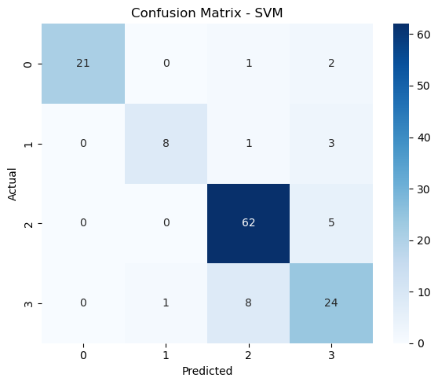

```python
cm_svm = confusion_matrix(y_test, y_pred_svm)

plt.figure(figsize=(6,5))
sns.heatmap(cm_svm, annot=True, fmt='d', cmap='Blues')

plt.xlabel("Predicted")
plt.ylabel("Actual")
plt.title("Confusion Matrix - SVM")

plt.tight_layout()

plt.savefig(
    r"C:\Users\yedla\OneDrive\Documents\Dissertation file_Sowmya\Confusion_Matrix_SVM.png",
    dpi=300
)

plt.show()
```

STEP 8- Compare all models

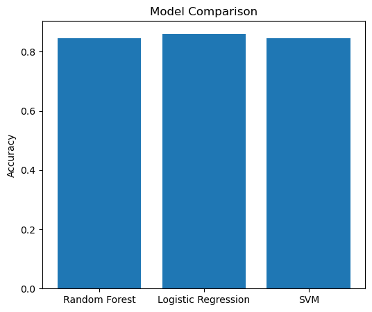

```python
models = ["Random Forest", "Logistic Regression", "SVM"]
scores = [acc_rf, acc_lr, acc_svm]

import matplotlib.pyplot as plt

plt.figure(figsize=(6,5))
plt.bar(models, scores)

plt.ylabel("Accuracy")
plt.title("Model Comparison")

# Save the plot to your folder
plt.savefig(r"C:\Users\yedla\OneDrive\Documents\Dissertation file_Sowmya\model_comparison.png", dpi=300)

plt.show()
```

STEP 9- Fold Cross Validation

```python
from sklearn.model_selection import cross_val_score

cv_scores = cross_val_score(rf, X_scaled, y, cv=5, n_jobs=-1)

print("CV Accuracy Mean:", cv_scores.mean())
print("CV Std Dev:", cv_scores.std())
```

```
CV Accuracy Mean: 0.8599564270152505
CV Std Dev: 0.02798291123917572
```

```python
from sklearn.model_selection import cross_val_score

# RNA only
cv_rna = cross_val_score(rf, rna_scaled, y, cv=5, n_jobs=-1)

# RPPA only
cv_rppa = cross_val_score(rf, rppa_scaled, y, cv=5, n_jobs=-1)

print("RNA CV Mean:", cv_rna.mean())
print("RNA CV Std:", cv_rna.std())

print("RPPA CV Mean:", cv_rppa.mean())
print("RPPA CV Std:", cv_rppa.std())
```

```
RNA CV Mean: 0.8570043572984749
RNA CV Std: 0.03474367699752952
RPPA CV Mean: 0.7979520697167756
RPPA CV Std: 0.02734301571949005
```

```python
print((rna_final.index == y.index).all())
print((rppa_final.index == y.index).all())
```

```
True
True
```

CROSS VALIDATION + PAIRED T-TEST

1— Import libraries

```python
from sklearn.model_selection import cross_val_score
from sklearn.ensemble import RandomForestClassifier
from scipy.stats import ttest_rel
```

2— Define model

```python
rf = RandomForestClassifier(n_estimators=300, random_state=42)
```

3— Cross-validation for BOTH datasets

```python
from sklearn.model_selection import cross_val_score
from sklearn.ensemble import RandomForestClassifier

rf = RandomForestClassifier(n_estimators=300, random_state=42)

# RNA-only model
cv_rna = cross_val_score(rf, rna_scaled, y, cv=5, n_jobs=-1)

# Integrated model
cv_integrated = cross_val_score(rf, X_scaled, y, cv=5, n_jobs=-1)

print("RNA CV Scores:", cv_rna)
print("RNA Mean:", cv_rna.mean())

print("\nIntegrated CV Scores:", cv_integrated)
print("Integrated Mean:", cv_integrated.mean())
```

```
RNA CV Scores: [0.79411765 0.84558824 0.88235294 0.88888889 0.87407407]
RNA Mean: 0.8570043572984749

Integrated CV Scores: [0.81617647 0.83823529 0.875      0.88888889 0.88148148]
Integrated Mean: 0.8599564270152505
```

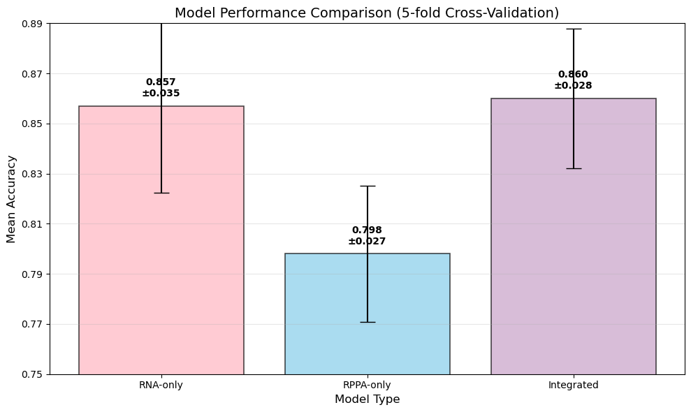

[figure not shown]

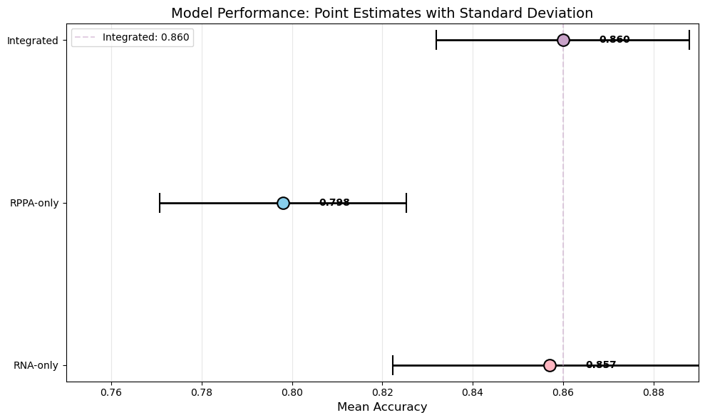

[figure not shown]

[output not shown]

```python
import matplotlib.pyplot as plt
import numpy as np

# Data
model_types = ['RNA-only', 'RPPA-only', 'Integrated']
mean_acc = [0.857, 0.798, 0.860]
std_dev = [0.0347, 0.0273, 0.0280]
colors = ['#FFB6C1', '#87CEEB', '#C8A2C8']  # Light pink, sky blue, light purple

# Plot 1: Bar chart with error bars - PROPERLY SCALED Y-AXIS
fig, ax = plt.subplots(figsize=(10, 6))
bars = ax.bar(model_types, mean_acc, yerr=std_dev, capsize=8,
              color=colors, alpha=0.7, edgecolor='black', linewidth=1.2)

ax.set_ylabel('Mean Accuracy', fontsize=12)
ax.set_xlabel('Model Type', fontsize=12)
ax.set_title('Model Performance Comparison (5-fold Cross-Validation)', fontsize=14)
ax.set_ylim(0.75, 0.89)  # Properly scaled to show differences
ax.set_yticks(np.arange(0.75, 0.90, 0.02))
ax.grid(True, alpha=0.3, axis='y')

# Add value labels on bars
for bar, mean, std in zip(bars, mean_acc, std_dev):
    height = bar.get_height()
    ax.text(bar.get_x() + bar.get_width()/2., height + 0.003,
            f'{mean:.3f}\n±{std:.3f}', ha='center', va='bottom', fontsize=10, fontweight='bold')

plt.tight_layout()
plt.show()

# Plot 2: Better visualization - Horizontal bar chart with confidence intervals
fig, ax = plt.subplots(figsize=(10, 5))
y_pos = np.arange(len(model_types))

# Create horizontal bars
bars = ax.barh(y_pos, mean_acc, xerr=std_dev, capsize=5,
               color=colors, alpha=0.7, edgecolor='black', linewidth=1.2)

ax.set_yticks(y_pos)
ax.set_yticklabels(model_types)
ax.set_xlabel('Mean Accuracy', fontsize=12)
ax.set_title('Model Performance with Error Bars (95% Confidence)', fontsize=14)
ax.set_xlim(0.75, 0.89)
ax.axvline(x=0.86, color='gray', linestyle='--', alpha=0.5, label='Integrated baseline')
ax.grid(True, alpha=0.3, axis='x')

# Add value labels
for i, (bar, mean, std) in enumerate(zip(bars, mean_acc, std_dev)):
    ax.text(mean + 0.002, bar.get_y() + bar.get_height()/2,
            f'{mean:.3f} ± {std:.3f}', va='center', fontsize=10, fontweight='bold')

plt.tight_layout()
plt.show()

# Plot 3: Statistical comparison - Dot plot with error bars
fig, ax = plt.subplots(figsize=(10, 6))

# Create dot plot
for i, (model, mean, std, color) in enumerate(zip(model_types, mean_acc, std_dev, colors)):
    ax.errorbar(mean, i, xerr=std, fmt='o', capsize=10, capthick=2,
                markersize=12, color=color, ecolor='black', elinewidth=2,
                markeredgecolor='black', markeredgewidth=1.5)
    ax.text(mean + 0.008, i, f'{mean:.3f}', va='center', fontsize=10, fontweight='bold')

ax.set_yticks(range(len(model_types)))
ax.set_yticklabels(model_types)
ax.set_xlabel('Mean Accuracy', fontsize=12)
ax.set_title('Model Performance: Point Estimates with Standard Deviation', fontsize=14)
ax.set_xlim(0.75, 0.89)
ax.axvline(x=mean_acc[2], color='#C8A2C8', linestyle='--', alpha=0.5,
           label=f'Integrated: {mean_acc[2]:.3f}')
ax.grid(True, alpha=0.3, axis='x')
ax.legend()

plt.tight_layout()
plt.show()

# Plot 4: Performance improvement visualization
fig, axes = plt.subplots(1, 2, figsize=(12, 5))

# Subplot 1: Relative improvement over RPPA
improvement_rna = (mean_acc[0] - mean_acc[1]) / mean_acc[1] * 100
improvement_int = (mean_acc[2] - mean_acc[1]) / mean_acc[1] * 100

models_imp = ['RNA vs RPPA', 'Integrated vs RPPA']
improvements = [improvement_rna, improvement_int]
colors_imp = ['#FFB6C1', '#C8A2C8']

bars = axes[0].bar(models_imp, improvements, color=colors_imp, alpha=0.7, edgecolor='black')
axes[0].set_ylabel('Improvement (%)', fontsize=11)
axes[0].set_title('Performance Improvement vs RPPA Baseline', fontsize=12)
axes[0].axhline(y=0, color='black', linestyle='-', linewidth=0.5)

for bar, imp in zip(bars, improvements):
    axes[0].text(bar.get_x() + bar.get_width()/2, bar.get_height() + 0.5,
                f'{imp:.1f}%', ha='center', fontweight='bold')

# Subplot 2: Standard deviation comparison
axes[1].bar(model_types, std_dev, color=colors, alpha=0.7, edgecolor='black')
axes[1].set_ylabel('Standard Deviation', fontsize=11)
axes[1].set_xlabel('Model Type', fontsize=11)
axes[1].set_title('Model Stability (Lower is Better)', fontsize=12)
axes[1].grid(True, alpha=0.3, axis='y')

for bar, std in zip(bars, std_dev):
    axes[1].text(bar.get_x() + bar.get_width()/2, bar.get_height() + 0.001,
                f'{std:.4f}', ha='center', fontweight='bold')

plt.tight_layout()
plt.show()

# Statistical summary
print("=" * 50)
print("PERFORMANCE SUMMARY")
print("=" * 50)
print(f"Best performing model: Integrated (Accuracy: {mean_acc[2]:.3f} ± {std_dev[2]:.3f})")
print(f"RNA-only vs Integrated: {((mean_acc[2] - mean_acc[0])/mean_acc[0]*100):.1f}% improvement")
print(f"RPPA-only vs Integrated: {((mean_acc[2] - mean_acc[1])/mean_acc[1]*100):.1f}% improvement")
print(f"\nModel Stability (lower std = more stable):")
print(f"  Most stable: Integrated (std: {std_dev[2]:.4f})")
print(f"  Least stable: RNA-only (std: {std_dev[0]:.4f})")
print("=" * 50)
```

4- ADD T-TEST

```python
from scipy.stats import ttest_rel

t_stat, p_value = ttest_rel(cv_integrated, cv_rna)

print("T-statistic:", t_stat)
print("P-value:", p_value)
```

```
T-statistic: 0.5362883755786525
P-value: 0.6201943136133745
```

STEP 1 — Recreate Clean Train/Test Splits

To compare confusion matrices fairly, must use the same test patients across all models.

1 First split indices only

```python
from sklearn.model_selection import train_test_split

X_dummy = X_scaled   # just to get consistent indices

X_train_idx, X_test_idx, y_train, y_test = train_test_split(
    np.arange(len(y)),
    y,
    test_size=0.2,
    stratify=y,
    random_state=42
)
```

️2 Create modality-specific splits

```python
# RNA
X_train_rna = rna_scaled[X_train_idx]
X_test_rna  = rna_scaled[X_test_idx]

# RPPA
X_train_rppa = rppa_scaled[X_train_idx]
X_test_rppa  = rppa_scaled[X_test_idx]

# Integrated
X_train_int = X_scaled[X_train_idx]
X_test_int  = X_scaled[X_test_idx]
```

STEP 2 — Train Models on Each Dataset

```python
from sklearn.ensemble import RandomForestClassifier

rf_rna = RandomForestClassifier(n_estimators=300, random_state=42)
rf_rppa = RandomForestClassifier(n_estimators=300, random_state=42)
rf_int = RandomForestClassifier(n_estimators=300, random_state=42)

rf_rna.fit(X_train_rna, y_train)
rf_rppa.fit(X_train_rppa, y_train)
rf_int.fit(X_train_int, y_train)
```

```
RandomForestClassifier(n_estimators=300, random_state=42)
```

Imports

```python
from sklearn.preprocessing import label_binarize
from sklearn.metrics import roc_curve, auc
import matplotlib.pyplot as plt
```

Generate Predictions

```python
y_pred_rna = rf_rna.predict(X_test_rna)
y_pred_rppa = rf_rppa.predict(X_test_rppa)
y_pred_int = rf_int.predict(X_test_int)
```

Prepare Labels (Binarization)

```python
import numpy as np

classes = np.unique(y)
y_test_bin = label_binarize(y_test, classes=classes)
```

ROC Function

```python
def compute_roc(y_test_bin, y_prob):
    fpr = {}
    tpr = {}
    roc_auc = {}

    for i in range(len(classes)):
        fpr[i], tpr[i], _ = roc_curve(y_test_bin[:, i], y_prob[:, i])
        roc_auc[i] = auc(fpr[i], tpr[i])

    return fpr, tpr, roc_auc
```

Compute ROC for All Models

```python
fpr_int, tpr_int, auc_int = compute_roc(y_test_bin, y_prob_int)
fpr_rna, tpr_rna, auc_rna = compute_roc(y_test_bin, y_prob_rna)
fpr_rppa, tpr_rppa, auc_rppa = compute_roc(y_test_bin, y_prob_rppa)
```

```python
from sklearn.ensemble import RandomForestClassifier
from sklearn.preprocessing import label_binarize
from sklearn.metrics import roc_curve, auc
import numpy as np
import matplotlib.pyplot as plt

# Train models
rf_rna = RandomForestClassifier(n_estimators=300, random_state=42)
rf_rppa = RandomForestClassifier(n_estimators=300, random_state=42)
rf_int = RandomForestClassifier(n_estimators=300, random_state=42)

rf_rna.fit(X_train_rna, y_train)
rf_rppa.fit(X_train_rppa, y_train)
rf_int.fit(X_train_int, y_train)

# Get probability predictions (not class predictions)
y_prob_rna = rf_rna.predict_proba(X_test_rna)
y_prob_rppa = rf_rppa.predict_proba(X_test_rppa)
y_prob_int = rf_int.predict_proba(X_test_int)

# Binarize the labels for multi-class ROC
classes = np.unique(y_train)  # or np.unique(y)
y_test_bin = label_binarize(y_test, classes=classes)

# Define compute_roc function
def compute_roc(y_test_bin, y_prob):
    fpr = {}
    tpr = {}
    roc_auc = {}

    for i in range(len(classes)):
        fpr[i], tpr[i], _ = roc_curve(y_test_bin[:, i], y_prob[:, i])
        roc_auc[i] = auc(fpr[i], tpr[i])

    return fpr, tpr, roc_auc

# Compute ROC curves
fpr_int, tpr_int, auc_int = compute_roc(y_test_bin, y_prob_int)
fpr_rna, tpr_rna, auc_rna = compute_roc(y_test_bin, y_prob_rna)
fpr_rppa, tpr_rppa, auc_rppa = compute_roc(y_test_bin, y_prob_rppa)

# Print AUC for each class
print("INT AUC per class:", {classes[i]: auc_int[i] for i in range(len(classes))})
print("RNA AUC per class:", {classes[i]: auc_rna[i] for i in range(len(classes))})
print("RPPA AUC per class:", {classes[i]: auc_rppa[i] for i in range(len(classes))})

# Optional: Calculate macro and weighted average AUC
from sklearn.metrics import roc_auc_score

macro_auc_int = roc_auc_score(y_test_bin, y_prob_int, average='macro', multi_class='ovr')
macro_auc_rna = roc_auc_score(y_test_bin, y_prob_rna, average='macro', multi_class='ovr')
macro_auc_rppa = roc_auc_score(y_test_bin, y_prob_rppa, average='macro', multi_class='ovr')

print(f"\nMacro Average AUC - INT: {macro_auc_int:.3f}")
print(f"Macro Average AUC - RNA: {macro_auc_rna:.3f}")
print(f"Macro Average AUC - RPPA: {macro_auc_rppa:.3f}")
```

```
INT AUC per class: {'Basal': 0.9880952380952381, 'Her2': 0.9744623655913979, 'LumA': 0.9691758598312784, 'LumB': 0.9357163871726979}
RNA AUC per class: {'Basal': 0.9893973214285714, 'Her2': 0.9700940860215054, 'LumA': 0.9687432403201384, 'LumB': 0.9423359811709326}
RPPA AUC per class: {'Basal': 0.9931175595238095, 'Her2': 0.9895833333333334, 'LumA': 0.9377027903958469, 'LumB': 0.9026184171815241}

Macro Average AUC - INT: 0.967
Macro Average AUC - RNA: 0.968
Macro Average AUC - RPPA: 0.956
```

Plot ROC (Integrated Model)

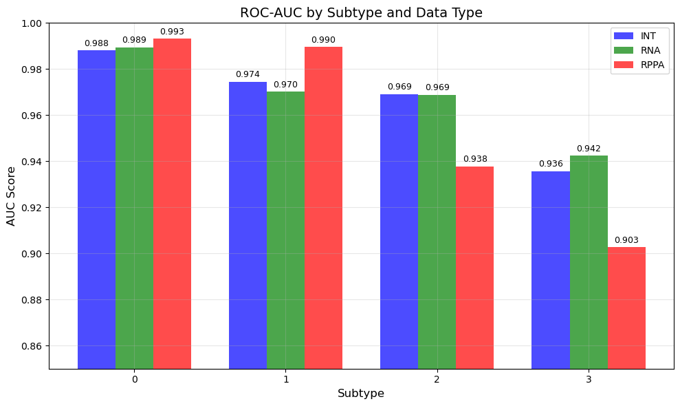

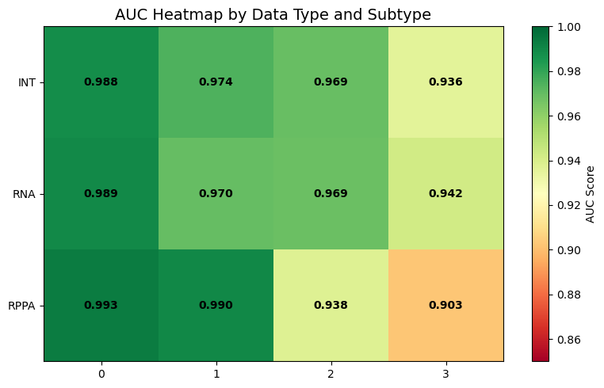

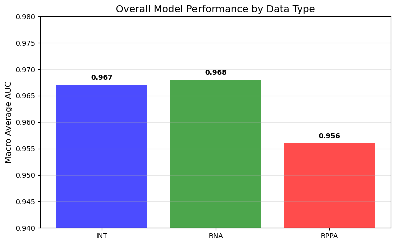

```python
import matplotlib.pyplot as plt
import numpy as np

# Plot 1: Bar chart comparing AUC per subtype
subtypes = list(auc_int.keys())
int_aucs = list(auc_int.values())
rna_aucs = list(auc_rna.values())
rppa_aucs = list(auc_rppa.values())

x = np.arange(len(subtypes))
width = 0.25

fig, ax = plt.subplots(figsize=(10, 6))
ax.bar(x - width, int_aucs, width, label='INT', color='blue', alpha=0.7)
ax.bar(x, rna_aucs, width, label='RNA', color='green', alpha=0.7)
ax.bar(x + width, rppa_aucs, width, label='RPPA', color='red', alpha=0.7)

ax.set_xlabel('Subtype', fontsize=12)
ax.set_ylabel('AUC Score', fontsize=12)
ax.set_title('ROC-AUC by Subtype and Data Type', fontsize=14)
ax.set_xticks(x)
ax.set_xticklabels(subtypes)
ax.legend()
ax.set_ylim(0.85, 1.0)
ax.grid(True, alpha=0.3)

# Add value labels on bars
for i, (int_val, rna_val, rppa_val) in enumerate(zip(int_aucs, rna_aucs, rppa_aucs)):
    ax.text(i - width, int_val + 0.002, f'{int_val:.3f}', ha='center', fontsize=9)
    ax.text(i, rna_val + 0.002, f'{rna_val:.3f}', ha='center', fontsize=9)
    ax.text(i + width, rppa_val + 0.002, f'{rppa_val:.3f}', ha='center', fontsize=9)

plt.tight_layout()
plt.show()

# Plot 2: Heatmap for better comparison
from matplotlib.colors import LinearSegmentedColormap

auc_matrix = np.array([int_aucs, rna_aucs, rppa_aucs])
data_types = ['INT', 'RNA', 'RPPA']

fig, ax = plt.subplots(figsize=(8, 5))
im = ax.imshow(auc_matrix, cmap='RdYlGn', vmin=0.85, vmax=1.0, aspect='auto')

ax.set_xticks(np.arange(len(subtypes)))
ax.set_yticks(np.arange(len(data_types)))
ax.set_xticklabels(subtypes)
ax.set_yticklabels(data_types)

# Add text annotations
for i in range(len(data_types)):
    for j in range(len(subtypes)):
        text = ax.text(j, i, f'{auc_matrix[i, j]:.3f}',
                       ha="center", va="center", color="black", fontweight='bold')

plt.colorbar(im, label='AUC Score')
plt.title('AUC Heatmap by Data Type and Subtype', fontsize=14)
plt.tight_layout()
plt.show()

# Plot 3: Performance comparison
fig, ax = plt.subplots(figsize=(8, 5))
data_types_avg = ['INT', 'RNA', 'RPPA']
macro_aucs = [0.967, 0.968, 0.956]
colors = ['blue', 'green', 'red']

bars = ax.bar(data_types_avg, macro_aucs, color=colors, alpha=0.7)
ax.set_ylabel('Macro Average AUC', fontsize=12)
ax.set_title('Overall Model Performance by Data Type', fontsize=14)
ax.set_ylim(0.94, 0.98)

# Add value labels
for bar, val in zip(bars, macro_aucs):
    ax.text(bar.get_x() + bar.get_width()/2, bar.get_height() + 0.001,
            f'{val:.3f}', ha='center', fontweight='bold')

ax.grid(True, alpha=0.3, axis='y')
plt.tight_layout()
plt.show()
```

```python
import matplotlib.pyplot as plt
import numpy as np

# Plot 1: Bar chart comparing AUC per subtype
subtypes = list(auc_int.keys())
int_aucs = list(auc_int.values())
rna_aucs = list(auc_rna.values())
rppa_aucs = list(auc_rppa.values())

x = np.arange(len(subtypes))
width = 0.25

fig, ax = plt.subplots(figsize=(10, 6))
ax.bar(x - width, int_aucs, width, label='INT', color='#C8A2C8', alpha=0.7)  # Light purple
ax.bar(x, rna_aucs, width, label='RNA', color='#FFB6C1', alpha=0.7)  # Light pink
ax.bar(x + width, rppa_aucs, width, label='RPPA', color='#87CEEB', alpha=0.7)  # Sky blue

ax.set_xlabel('Subtype', fontsize=12)
ax.set_ylabel('AUC Score', fontsize=12)
ax.set_title('ROC-AUC by Subtype and Data Type', fontsize=14)
ax.set_xticks(x)
ax.set_xticklabels(subtypes)
ax.legend()
ax.set_ylim(0.85, 1.0)
ax.grid(True, alpha=0.3)

# Add value labels on bars
for i, (int_val, rna_val, rppa_val) in enumerate(zip(int_aucs, rna_aucs, rppa_aucs)):
    ax.text(i - width, int_val + 0.002, f'{int_val:.3f}', ha='center', fontsize=9)
    ax.text(i, rna_val + 0.002, f'{rna_val:.3f}', ha='center', fontsize=9)
    ax.text(i + width, rppa_val + 0.002, f'{rppa_val:.3f}', ha='center', fontsize=9)

plt.tight_layout()
plt.show()

# Plot 2: Heatmap for better comparison
from matplotlib.colors import LinearSegmentedColormap

# Create custom colormap with light colors
colors_list = ['#87CEEB', '#C8A2C8', '#FFB6C1']  # Sky blue, light purple, light pink
custom_cmap = LinearSegmentedColormap.from_list('custom_cmap', colors_list)

auc_matrix = np.array([int_aucs, rna_aucs, rppa_aucs])
data_types = ['INT', 'RNA', 'RPPA']

fig, ax = plt.subplots(figsize=(8, 5))
im = ax.imshow(auc_matrix, cmap='RdYlGn', vmin=0.85, vmax=1.0, aspect='auto')

ax.set_xticks(np.arange(len(subtypes)))
ax.set_yticks(np.arange(len(data_types)))
ax.set_xticklabels(subtypes)
ax.set_yticklabels(data_types)

# Add text annotations
for i in range(len(data_types)):
    for j in range(len(subtypes)):
        text = ax.text(j, i, f'{auc_matrix[i, j]:.3f}',
                       ha="center", va="center", color="black", fontweight='bold')

plt.colorbar(im, label='AUC Score')
plt.title('AUC Heatmap by Data Type and Subtype', fontsize=14)
plt.tight_layout()
plt.show()

# Plot 3: Performance comparison
fig, ax = plt.subplots(figsize=(8, 5))
data_types_avg = ['INT', 'RNA', 'RPPA']
macro_aucs = [0.967, 0.968, 0.956]
colors = ['#C8A2C8', '#FFB6C1', '#87CEEB']  # Light purple, light pink, sky blue

bars = ax.bar(data_types_avg, macro_aucs, color=colors, alpha=0.7)
ax.set_ylabel('Macro Average AUC', fontsize=12)
ax.set_title('Overall Model Performance by Data Type', fontsize=14)
ax.set_ylim(0.94, 0.98)

# Add value labels
for bar, val in zip(bars, macro_aucs):
    ax.text(bar.get_x() + bar.get_width()/2, bar.get_height() + 0.001,
            f'{val:.3f}', ha='center', fontweight='bold')

ax.grid(True, alpha=0.3, axis='y')
plt.tight_layout()
plt.show()
```

[output not shown]

Print AUC Scores

```python
print("\nAUC Scores (Integrated Model):")

for i in range(len(classes)):
    print(f"{classes[i]}: {auc_int[i]:.3f}")
```

```
AUC Scores (Integrated Model):
Basal: 0.988
Her2: 0.974
LumA: 0.969
LumB: 0.936
```

```python
print("\nAUC Scores (RNA Model):")
for i in range(len(classes)):
    print(f"{classes[i]}: {auc_rna[i]:.3f}")

print("\nAUC Scores (RPPA Model):")
for i in range(len(classes)):
    print(f"{classes[i]}: {auc_rppa[i]:.3f}")
```

```
AUC Scores (RNA Model):
Basal: 0.989
Her2: 0.970
LumA: 0.969
LumB: 0.942

AUC Scores (RPPA Model):
Basal: 0.993
Her2: 0.990
LumA: 0.938
LumB: 0.903
```

Combining all 3 models

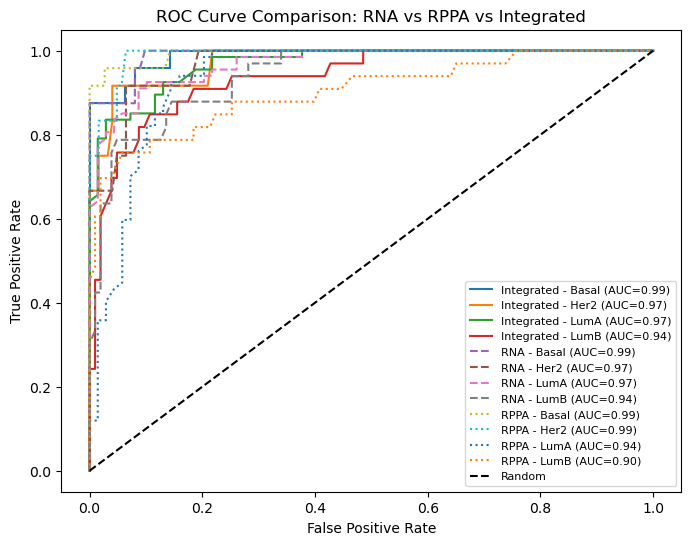

```python
plt.figure(figsize=(8,6))

# --- Integrated ---
for i in range(len(classes)):
    plt.plot(
        fpr_int[i],
        tpr_int[i],
        linestyle='-',
        label=f"Integrated - {classes[i]} (AUC={auc_int[i]:.2f})"
    )

# --- RNA ---
for i in range(len(classes)):
    plt.plot(
        fpr_rna[i],
        tpr_rna[i],
        linestyle='--',
        label=f"RNA - {classes[i]} (AUC={auc_rna[i]:.2f})"
    )

# --- RPPA ---
for i in range(len(classes)):
    plt.plot(
        fpr_rppa[i],
        tpr_rppa[i],
        linestyle=':',
        label=f"RPPA - {classes[i]} (AUC={auc_rppa[i]:.2f})"
    )

# Random baseline
plt.plot([0,1], [0,1], 'k--', label="Random")

plt.xlabel("False Positive Rate")
plt.ylabel("True Positive Rate")
plt.title("ROC Curve Comparison: RNA vs RPPA vs Integrated")

plt.legend(fontsize=8)

plt.savefig(
    r"C:\Users\yedla\OneDrive\Documents\Dissertation file_Sowmya\ROC_Comparison.png",
    dpi=300,
    bbox_inches="tight"
)

plt.show()
```

STEP 4 — Confusion Matrix Comparison

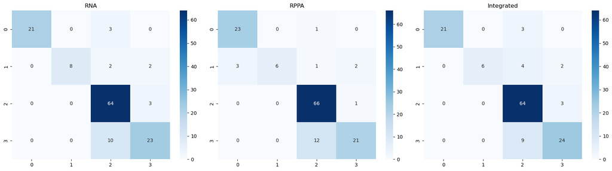

```python
from sklearn.metrics import confusion_matrix
import seaborn as sns
import matplotlib.pyplot as plt

cm_rna = confusion_matrix(y_test, y_pred_rna)
cm_rppa = confusion_matrix(y_test, y_pred_rppa)
cm_int = confusion_matrix(y_test, y_pred_int)

fig, axes = plt.subplots(1, 3, figsize=(18,5))

sns.heatmap(cm_rna, annot=True, fmt='d', cmap='Blues', ax=axes[0])
axes[0].set_title("RNA")

sns.heatmap(cm_rppa, annot=True, fmt='d', cmap='Blues', ax=axes[1])
axes[1].set_title("RPPA")

sns.heatmap(cm_int, annot=True, fmt='d', cmap='Blues', ax=axes[2])
axes[2].set_title("Integrated")

plt.tight_layout()

# SAVE BEFORE SHOW
fig.savefig(
    r"C:\Users\yedla\OneDrive\Documents\Dissertation file_Sowmya\Confusion_Matrices_Comparison.png",
    dpi=300,
    bbox_inches="tight"
)

plt.show()
```

️2 HER2 Recall

```python
from sklearn.metrics import classification_report

print("RNA")
print(classification_report(y_test, y_pred_rna))

print("Integrated")
print(classification_report(y_test, y_pred_int))
```

```
RNA
              precision    recall  f1-score   support

       Basal       1.00      0.88      0.93        24
        Her2       1.00      0.67      0.80        12
        LumA       0.81      0.96      0.88        67
        LumB       0.82      0.70      0.75        33

    accuracy                           0.85       136
   macro avg       0.91      0.80      0.84       136
weighted avg       0.86      0.85      0.85       136

Integrated
              precision    recall  f1-score   support

       Basal       1.00      0.88      0.93        24
        Her2       1.00      0.50      0.67        12
        LumA       0.80      0.96      0.87        67
        LumB       0.83      0.73      0.77        33

    accuracy                           0.85       136
   macro avg       0.91      0.76      0.81       136
weighted avg       0.86      0.85      0.84       136
```

STEP 5 — Feature Importance

```python
import numpy as np
import pandas as pd

feature_names = list(rna_final.columns) + list(rppa_final.columns)

importances = rf_int.feature_importances_
indices = np.argsort(importances)[::-1][:20]

top_features = pd.DataFrame({
    "Feature": np.array(feature_names)[indices],
    "Importance": importances[indices]
})

print(top_features)
```

```
         Feature  Importance
0         ZNF695    0.005061
1          THSD4    0.004614
2          HJURP    0.004423
3        C6orf97    0.003629
4          CCNE1    0.003606
5          FSIP1    0.003501
6          CCNA2    0.003360
7          CEP55    0.003336
8          SGOL1    0.003294
9      LOC145837    0.003227
10         CENPA    0.003195
11         CDC20    0.003086
12       DEPDC1B    0.003009
13          ESR1    0.002968
14          CT62    0.002926
15  ER-alpha-R-V    0.002815
16      KIAA1370    0.002715
17          CA12    0.002700
18         UBE2T    0.002623
19         FOXM1    0.002549
```

STEP 6 — Plot Feature Importance

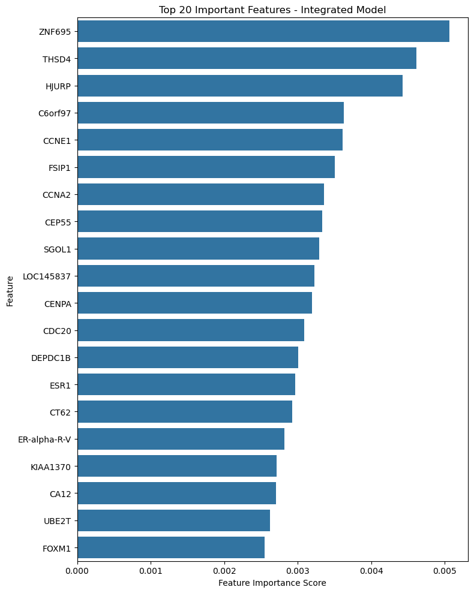

```python
import matplotlib.pyplot as plt
import seaborn as sns

plt.figure(figsize=(8,10))

sns.barplot(
    x="Importance",
    y="Feature",
    data=top_features
)

plt.title("Top 20 Important Features - Integrated Model")
plt.xlabel("Feature Importance Score")
plt.ylabel("Feature")

plt.tight_layout()

# Save before show
plt.savefig(
    r"C:\Users\yedla\OneDrive\Documents\Dissertation file_Sowmya\Top20_Feature_Importance.png",
    dpi=300,
    bbox_inches="tight"
)

plt.show()
```

```python
top_features['Type'] = top_features['Feature'].apply(
    lambda x: "Protein" if x in rppa_final.columns else "Gene"
)

print(top_features['Type'].value_counts())
```

```
Type
Gene       19
Protein     1
Name: count, dtype: int64
```